# Linear Models

# 8 Analysis: Interactions and Marginal Effects

Although interactions are uncommon in regression, how do we formulate and interpret them correctly? Normally, we have substantive reasons and theory for creating an interaction. An interaction term states that one variable *depends* on the level of another. Here, we have created one for show, whereby adult literacy is dependent on the level of inequality in a country.

We aim for marginal effects with continuous interactions which means we take the first partial derivative of the expected value of $Y$ (life satisfaction) with respect to adult literacy.

$$\frac{\partial E(\text{life satisfaction}_i)}{\partial \text{adult literacy}_i} = \beta_1 + \beta_5\text{inequality}_i.$$
First we run the model:

```r
fit1 <- lm(UNSATI ~ UNLIT + UN_GINI + log(UNGDPCAP, base = 1.1) +
             log(UNPOP10) + UNLIT*UN_GINI,  data = df)
summary(fit1)
```

```
##
## Call:
## lm(formula = UNSATI ~ UNLIT + UN_GINI + log(UNGDPCAP, base = 1.1) +
##     log(UNPOP10) + UNLIT * UN_GINI, data = df)
##
## Residuals:
##      Min       1Q   Median       3Q      Max
## -2.50437 -0.45556 -0.00166  0.46892  2.07966
##
## Coefficients:
##                             Estimate Std. Error t value Pr(>|t|)
## (Intercept)                6.6847467  2.6881924   2.487 0.014620 *
## UNLIT                     -0.0567818  0.0297263  -1.910 0.059098 .
## UN_GINI                   -0.1461452  0.0635925  -2.298 0.023723 *
## log(UNGDPCAP, base = 1.1)  0.0303350  0.0076349   3.973 0.000137 ***
## log(UNPOP10)               0.0861714  0.0701704   1.228 0.222438
## UNLIT:UN_GINI              0.0020153  0.0007347   2.743 0.007262 **
## ---
## Signif. codes:  0 '***' 0.001 '**' 0.01 '*' 0.05 '.' 0.1 ' ' 1
##
## Residual standard error: 0.9274 on 96 degrees of freedom
##   (151 observations deleted due to missingness)
## Multiple R-squared:  0.4977, Adjusted R-squared:  0.4715
## F-statistic: 19.02 on 5 and 96 DF,  p-value: 4.187e-13
```

Then we pull the beta coefficients.

```r
beta_lit <- fit1$coefficients[2]
beta_interaction <- fit1$coefficients[6]
```

Then sequence adult literacy.

```r
sq_lit <- seq(from = min(df_controls$UNLIT),
              to = max(df_controls$UNLIT), length.out = 10)
```

And calculate the marginal effect:

```r
marg.effect <- beta_lit + beta_interaction*sq_lit
ME <- data.frame(sq_lit, marg.effect)
kable(ME)
```

| sq_lit | marg.effect |
| --- | --- |
| 26.16667 | -0.0040489 |
| 34.34444 | 0.0124315 |
| 42.52222 | 0.0289120 |
| 50.70000 | 0.0453924 |
| 58.87778 | 0.0618728 |
| 67.05556 | 0.0783532 |
| 75.23333 | 0.0948336 |
| 83.41111 | 0.1113141 |
| 91.58889 | 0.1277945 |
| 99.76667 | 0.1442749 |

# 9 Analysis: Marginal Effect Standard Errors

```r
coef <- coef(fit1) # pull coefs
sigma <- vcov(fit1) # pull variance-covariance matrix
sim.betas <- data.frame(mvrnorm(n = 1000, mu = coef, Sigma=sigma)) # simulate
sim.betas <- dplyr::select(sim.betas, UNLIT, UNLIT.UN_GINI) # pull beta and interaction term
head(sim.betas)
```

```
##         UNLIT UNLIT.UN_GINI
## 1 -0.14633756  0.0041983082
## 2 -0.06978633  0.0022529103
## 3 -0.00745908  0.0008181124
## 4 -0.05231454  0.0017624026
## 5 -0.02849129  0.0014858894
## 6 -0.02989192  0.0012247231
```

```r
sq_lit <- as.data.frame(sq_lit) # transform sequence to a dataframe
sq_lit <- mutate(sq_lit, one = 1) # add a variable for easy joining
sim.betas <- mutate(sim.betas, one = 1) # do the same
ME <- full_join(sim.betas, sq_lit) # join the data
ME <- mutate(ME, marg.effect = UNLIT # calcualte marginal effect
             + UNLIT.UN_GINI*sq_lit) # beta + interaction term * sequenced x-variable
```

```r
ME <- ME %>%
      group_by(sq_lit) %>%
  summarize(me = mean(marg.effect),
            LB = quantile(marg.effect, .025),
            UB = quantile(marg.effect, .975))
ME
```

```
## # A tibble: 10 x 4
##    sq_lit       me       LB     UB
##     <dbl>    <dbl>    <dbl>  <dbl>
##  1   26.2 -0.00386 -0.0283  0.0189
##  2   34.3  0.0125  -0.00226 0.0261
##  3   42.5  0.0289   0.0171  0.0421
##  4   50.7  0.0453   0.0258  0.0654
##  5   58.9  0.0617   0.0322  0.0916
##  6   67.1  0.0780   0.0371  0.119
##  7   75.2  0.0944   0.0424  0.149
##  8   83.4  0.111    0.0464  0.178
##  9   91.6  0.127    0.0498  0.204
## 10   99.8  0.144    0.0550  0.231
```

## 9.1 Analysis: Interactions and Marginal Effects Graphs

```r
plot_ly(data = ME, type = 'scatter', mode = 'lines') %>%
  add_trace(x=~sq_lit, y=~me, name = 'Marginal Effect', line = list(color='rgb(0,100,80)')) %>%
  add_trace(x =~sq_lit, y =~UB, line = list(color = 'transparent'),
            name = 'Upper CI', showlegend = FALSE) %>%
  add_trace(x =~sq_lit, y =~LB, fill = 'tonexty', fillcolor='rgba(0,100,80,0.2)',
            line = list(color = 'transparent'), name = 'Lower CI', showlegend = FALSE) %>%
  layout(xaxis = list(dtick = 10))
```

[interactive chart not shown]

Interpretation:

# 10 OLS Assumptions Check

## 10.1 Zero Conditional Mean

A violation of the zero conditional mean assumption risks biased coefficients. We check for violations of the zero conditional mean in the plot below, which depicts our residuals by a linear combination of our independent variables. In the plot, we look for a roughly flat red line along zero. We can see that the red line is indeed mostly flat with some slight curvatures towards the ends, likely owing to the fact that we have limited observations. We therefore assess that our primary model does not violate this assumption.

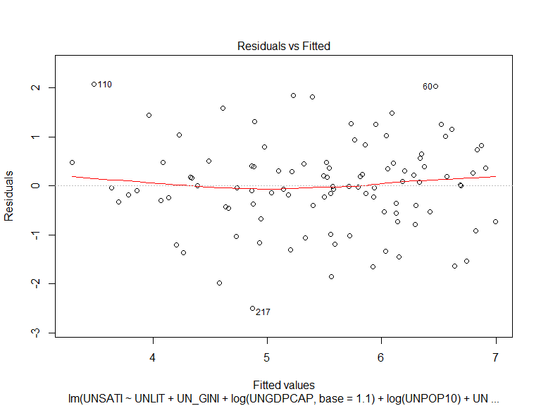

```r
plot(fit1, which = 1)
```

## 10.2 Homoskedasticity

The assumption of homoskedastic error consists of the following two components:

1. $\epsilon_{i}$ is independent of $\epsilon_{j}$ conditional on X for all $i$ $\neq$ $j$.
2. The variance of the error does not depend on the predictor: Var($\epsilon_{i}$|X) = Var($\epsilon_{i}$)

The assumption that all the errors have the same variance is called homoskedasticity.

The null for the Breusch-Pagan test is homoskedasticity. Given the results of our test; we reject the null and assume we have hetereoskedasticity. However, we need to be cautious about this test as it is sensitive to the number of observations.

```r
library(lmtest)
library(sandwich)
bptest(fit1)
```

```
##
##  studentized Breusch-Pagan test
##
## data:  fit1
## BP = 17.795, df = 5, p-value = 0.003214
```

We might also suspect evidence of heteroskedasticity in our plot below which shows some unevenness in the scatter plot particularly around the center values as they cluster further toward the right. However, it does not look too bad.

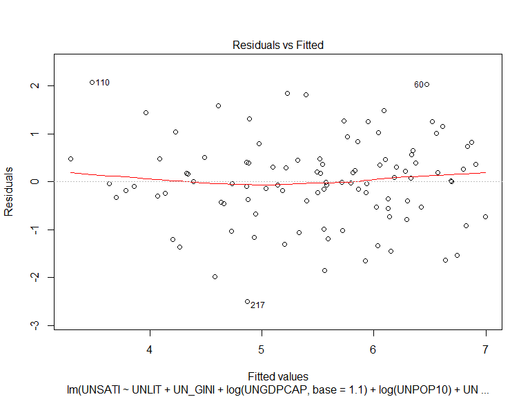

```r
plot(fit1, which = 1)
```

We can also judge heteroskedasticity from the next plot which if it showed a non-flat line. If we had homoskedastic data, the red line would be roughly flat, which is what we see.

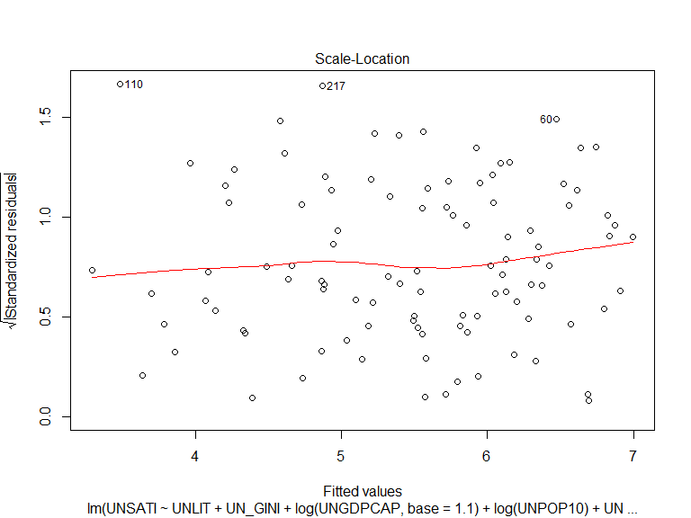

```r
plot(fit1, which = 3)
```

## 10.3 Normality of Errors

The normality of errors assumes that the errors must have this specific distribution:

$$\begin{eqnarray}
\epsilon \sim N(0, \sigma^2), &\\
Corr(\epsilon_{j}, \epsilon_{k}) = 0, \forall j \neq k
\end{eqnarray}$$

Which means:

1. all errors are normally distributed with a mean of 0,
2. all errors are independent from one another,
3. and all errors have the same variance.

If the errors are not normally distributed, or do not have a mean of 0, then we say we have a model misspecification problem. If the errors are not independent from one another, we have an autocorrelation problem.

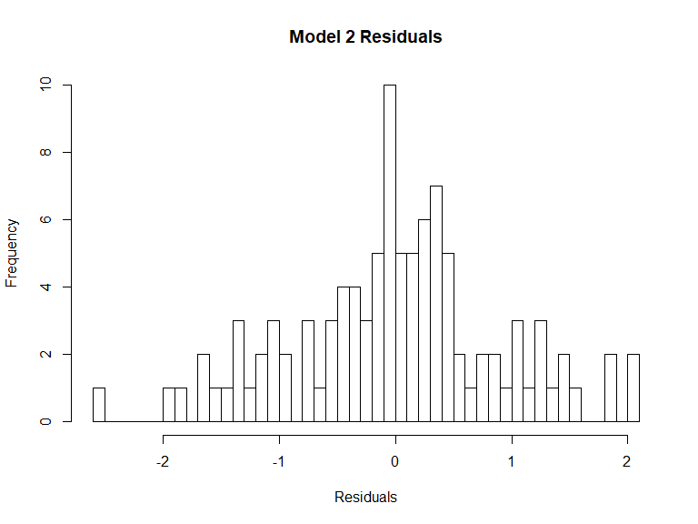

```r
hist(fit1$residuals, breaks = 50, main = "Model 2 Residuals", xlab="Residuals")
```

```r
shapiro.test(fit1$residuals)
```

```
##
##  Shapiro-Wilk normality test
##
## data:  fit1$residuals
## W = 0.98825, p-value = 0.5124
```

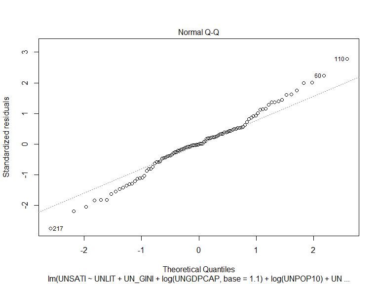

```r
# qq plot
plot(fit1, which = 2)
```

# 11 Sources

- Kropko, Jonathan. PLAD 8320: Generalized Linear Models. University of Virginia.
- Finke, Roger, and Brian J. Grim. “Cross-National Socio-Economic and Religion Data, 2011.” The Association of Religion Data Archives (2011).[Data](http://thearda.com/Archive/Files/Descriptions/ECON11.asp)